# R you ready to ggplot2?

### Position adjustment: identity

```
  year state stores
1 2005    FL    174
2 2005    MI     76
3 2005    NJ     41
4 2005    NV     22
5 2005    VT      4
```

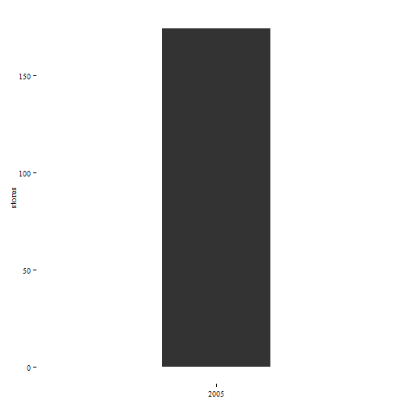

```r
aes(x = year,y = stores)
data = mini_walmart
geom_bar()
position = identity
```

### Position adjustment: identity

Why do we have only 1 bar instead of 5? In reality, there are 5 bars on this plot, but since they **overlap** and are of the **same color**, we cannot distinguish them.

## Let's add some colors!

[figure not shown]

### Position adjustment: identity

```
  year state stores
1 2005    FL    174
2 2005    MI     76
3 2005    NJ     41
4 2005    NV     22
5 2005    VT      4
```

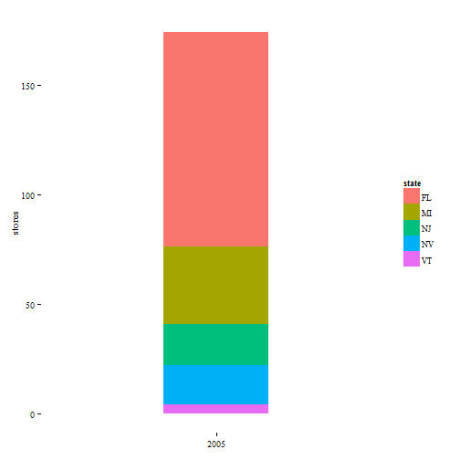

```r
aes(x = year,y = stores,
   fill = state)
data = mini_walmart
geom_bar()
position = identity
```

### Position adjustment: dodge

```
  year state stores
1 2005    FL    174
2 2005    MI     76
3 2005    NJ     41
4 2005    NV     22
5 2005    VT      4
```

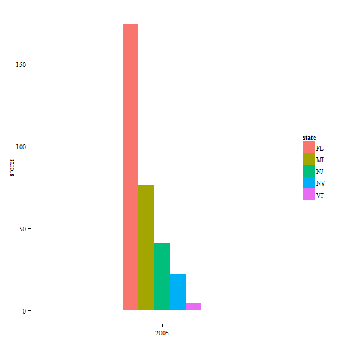

```r
aes(x = year,y = stores,
   fill = state)
data = mini_walmart
geom_bar()
position = dodge
```

### Position adjustment: stack

```
  year state stores
1 2005    FL    174
2 2005    MI     76
3 2005    NJ     41
4 2005    NV     22
5 2005    VT      4
```

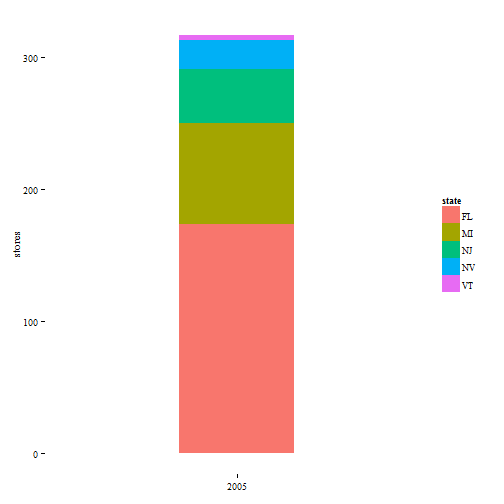

```r
aes(x = year,y = stores,
    fill = state)
data = mini_walmart
geom_bar()
position = stack
```

### Position adjustment: fill

```
  year state stores
1 2005    FL    174
2 2005    MI     76
3 2005    NJ     41
4 2005    NV     22
5 2005    VT      4
```

```r
aes(x = year,y = stores,
    fill = state)
data = mini_walmart
geom_bar()
position = fill
```

[output not shown]

### COORDINATE SYSTEM: cartesian

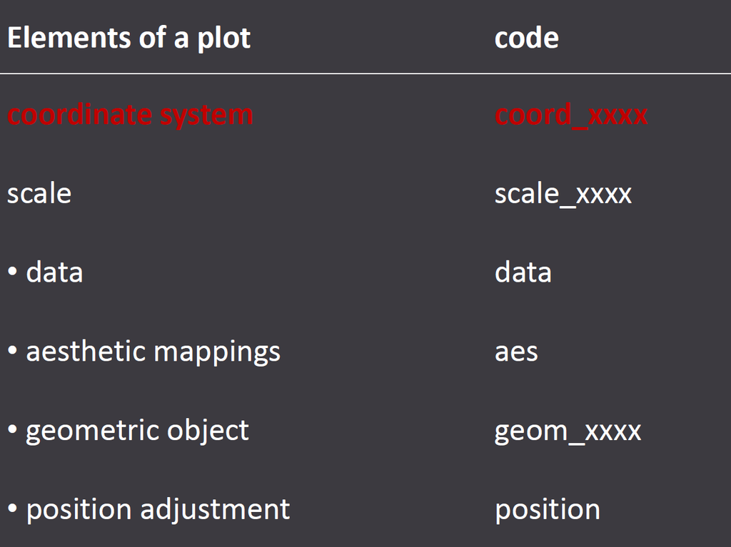

### COORDINATE SYSTEM: cartesian

```
  year state stores
1 2005    FL    174
2 2005    MI     76
3 2005    NJ     41
4 2005    NV     22
5 2005    VT      4
```

```r
aes(x = year,y = stores,
   fill = state)
data = mini_walmart
geom_bar()
position = fill
```

### COORDINATE SYSTEM: cartesian

```
  year state stores
1 2005    FL    174
2 2005    MI     76
3 2005    NJ     41
4 2005    NV     22
5 2005    VT      4
```

```r
aes(x = year,y = stores,
   fill = state)
data = mini_walmart
geom_bar()
position = fill
coord_cartesian()
```

```
  year state stores
1 2005    FL    174
2 2005    MI     76
3 2005    NJ     41
4 2005    NV     22
5 2005    VT      4
```

```r
aes(x = year,y = stores,
    fill = state)
data = mini_walmart
geom_bar()
position = fill
coord_polar()
```

TAKE A GUESS: WHAT WILL THIS PLOT LOOK LIKE?

```
  year state stores
1 2005    FL    174
2 2005    MI     76
3 2005    NJ     41
4 2005    NV     22
5 2005    VT      4
```

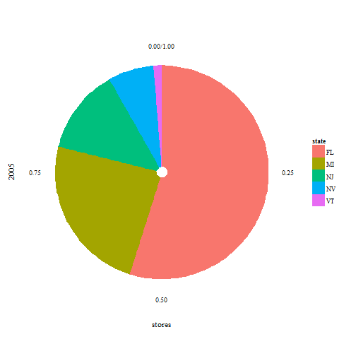

```r
aes(x = year,y = stores,
    fill = state)
data = mini_walmart
geom_bar()
position = fill
coord_polar()
```

**pie chart = stacked bar chart** in polar coordinates coordinate system!

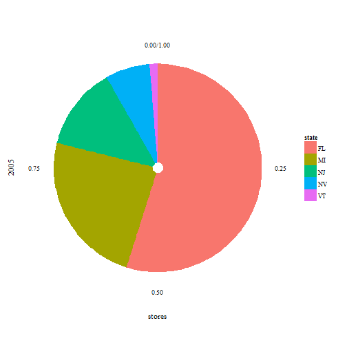

## PRACTICE TIME!!

## Add a regression line to your hand drawn scatter plot

## PRACTICE TIME!!

## What additional step do you need to take?

### STATISTICAL TRANSFORMATION

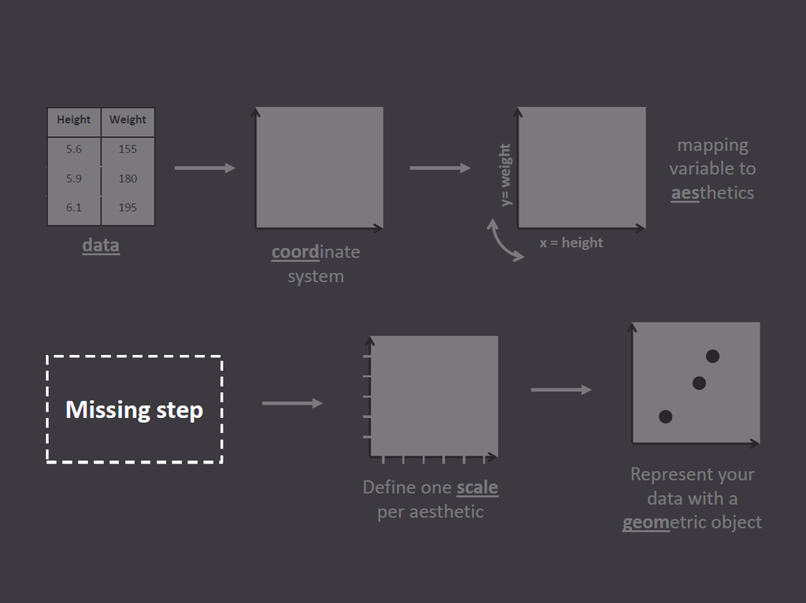

In order to plot your regression line, you first need to estimate this regression line, and compute the **predicted values** for your dataset.

### STATISTICAL TRANSFORMATION

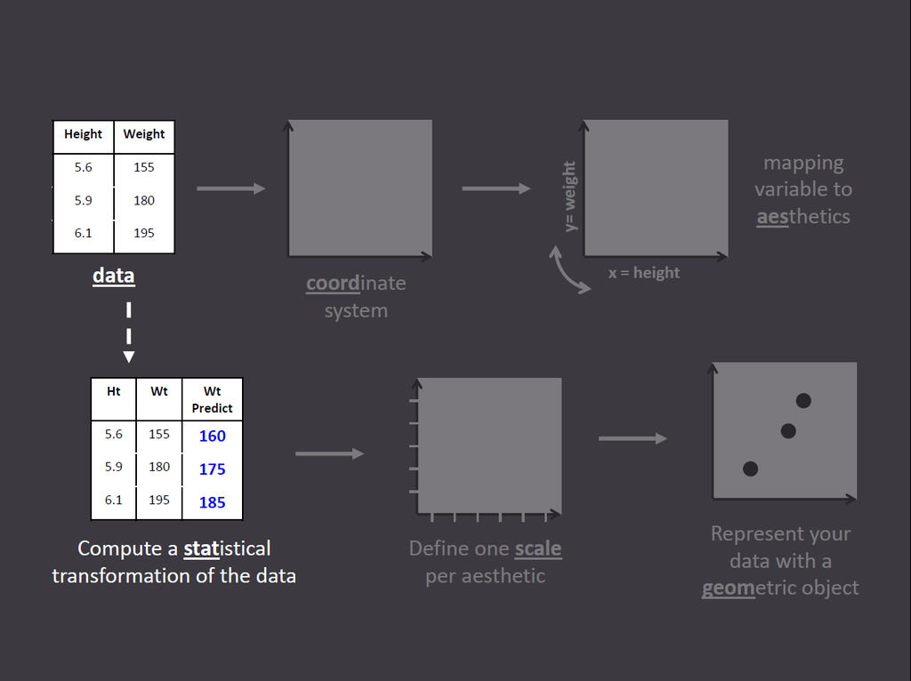

### STATISTICAL TRANSFORMATION

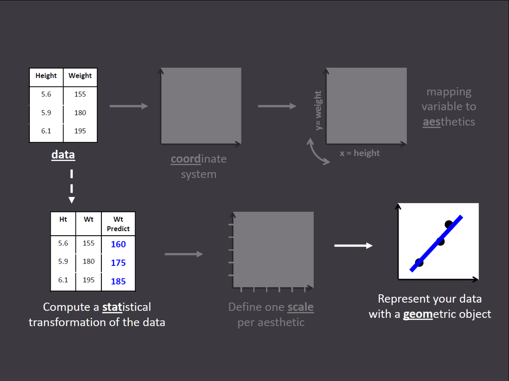

### STATISTICAL TRANSFORMATION

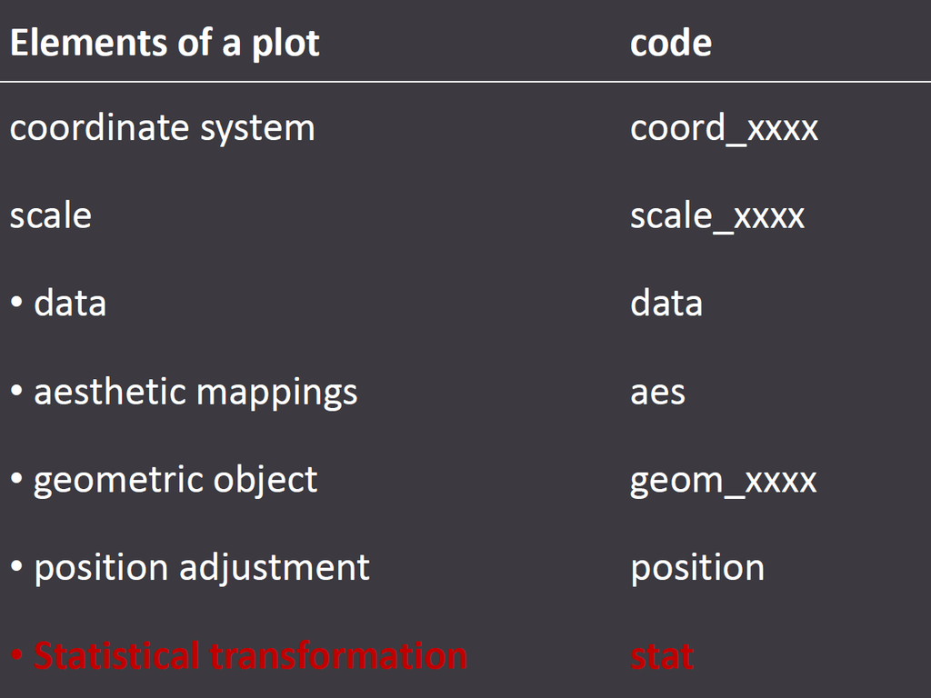

### STATISTICAL TRANSFORMATION: identity

```
  year state stores share
1 2005    FL    174  0.40
2 2005    MI     76  0.30
3 2005    NJ     41  0.15
4 2005    NV     22  0.10
5 2005    VT      4  0.05
```

```r
aes(x = stores, y = share)
data = mini_walmart
geom_point()
```

### STATISTICAL TRANSFORMATION: identity

```
  year state stores share
1 2005    FL    174  0.40
2 2005    MI     76  0.30
3 2005    NJ     41  0.15
4 2005    NV     22  0.10
5 2005    VT      4  0.05
```

```r
aes(x = stores, y = share)
data = mini_walmart
geom_point(stat = 'identity')
```

### STATISTICAL TRANSFORMATION: smooth

```
  year state stores share
1 2005    FL    174  0.40
2 2005    MI     76  0.30
3 2005    NJ     41  0.15
4 2005    NV     22  0.10
5 2005    VT      4  0.05
```

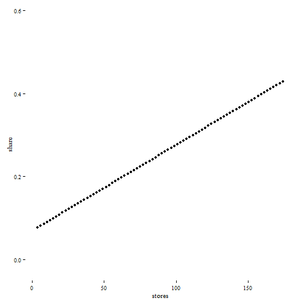

```r
aes(x = stores, y = share)
data = mini_walmart
geom_point(stat = 'smooth')
```

### STATISTICAL TRANSFORMATION: smooth

```
  year state stores share
1 2005    FL    174  0.40
2 2005    MI     76  0.30
3 2005    NJ     41  0.15
4 2005    NV     22  0.10
5 2005    VT      4  0.05
```

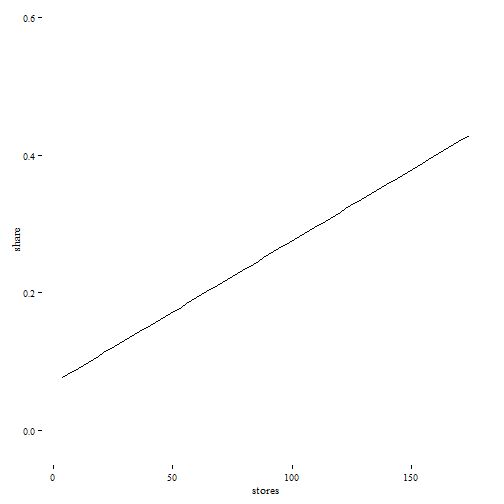

```r
aes(x = stores, y = share)
data = mini_walmart
geom_line(stat = 'smooth')
```

### LAYER

```
  year state stores share
1 2005    FL    174  0.40
2 2005    MI     76  0.30
3 2005    NJ     41  0.15
4 2005    NV     22  0.10
5 2005    VT      4  0.05
```

```r
aes(x = stores, y = share)
data = mini_walmart
geom_point(stat = 'identity')
```

### LAYER

```
  year state stores share
1 2005    FL    174  0.40
2 2005    MI     76  0.30
3 2005    NJ     41  0.15
4 2005    NV     22  0.10
5 2005    VT      4  0.05
```

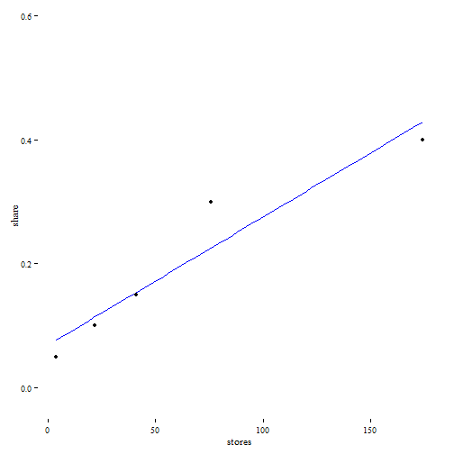

```r
aes(x = stores, y = share)
data = mini_walmart
geom_point(stat = 'identity') +
geom_line(stat = 'smooth')
```

### LAYER

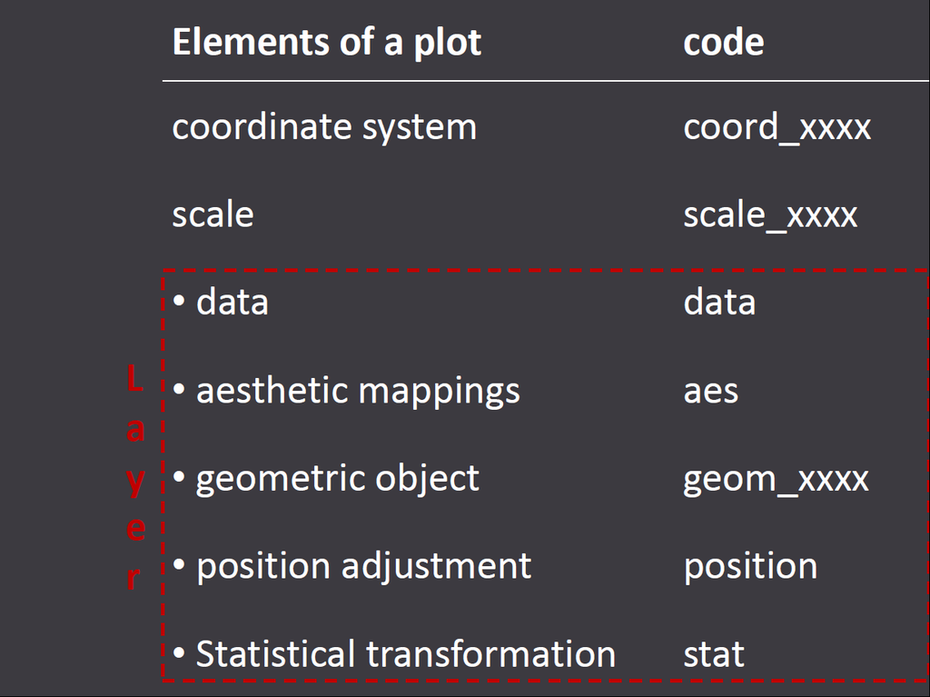

### LAYER

## In the Grammar of Graphics framework, one plot is made of:

- ONE coordinate system
- As many scales as there are aesthetics
- ONE or MULTIPLE layers